# Assignment 10: Predictive Modeling - Part 1

*How to do it?*:

- Open the Rmarkdown file of this assignment (link) in Rstudio.
- Right under each **question**, insert a code chunk (you can use the hotkey `Ctrl + Alt + I` to add a code chunk) and code the solution for the question.
- `Knit` the rmarkdown file (hotkey: `Ctrl + Alt + K`) to export an html.
- Publish the html file to your Githiub Page.

*Submission*: Submit the link on Github of the assignment to Canvas

1. Install the package `mlbench` and use the follows to import the data

```r
library(mlbench)
data(PimaIndiansDiabetes)
df <- PimaIndiansDiabetes
```

- Set seed to be 2020.
- The target variable is `diabetes`
- Partition the data into 80% training and 20% testing.

```r
library(mlbench)
library(caret)
library(rpart)
data(PimaIndiansDiabetes)
df <- PimaIndiansDiabetes

set.seed(2020)

names(df)[9] <- 'target'

df$target <- factor(df$target)

df$age[is.na(df$age)] = mean(df$age, na.rm = TRUE)

splitIndex <- createDataPartition(df$target, p = .80, list = FALSE)
df_train <-  df[ splitIndex,]
df_test <- df[ -splitIndex,]
```

2. Practice Decision Tree. Do the follows:
- Use `rpart` package, create a decision tree with maximum depth of 3.
- Calculate the accuracy of the model on the testing data.
- Plot the tree
- Plot the variable importance by the tree

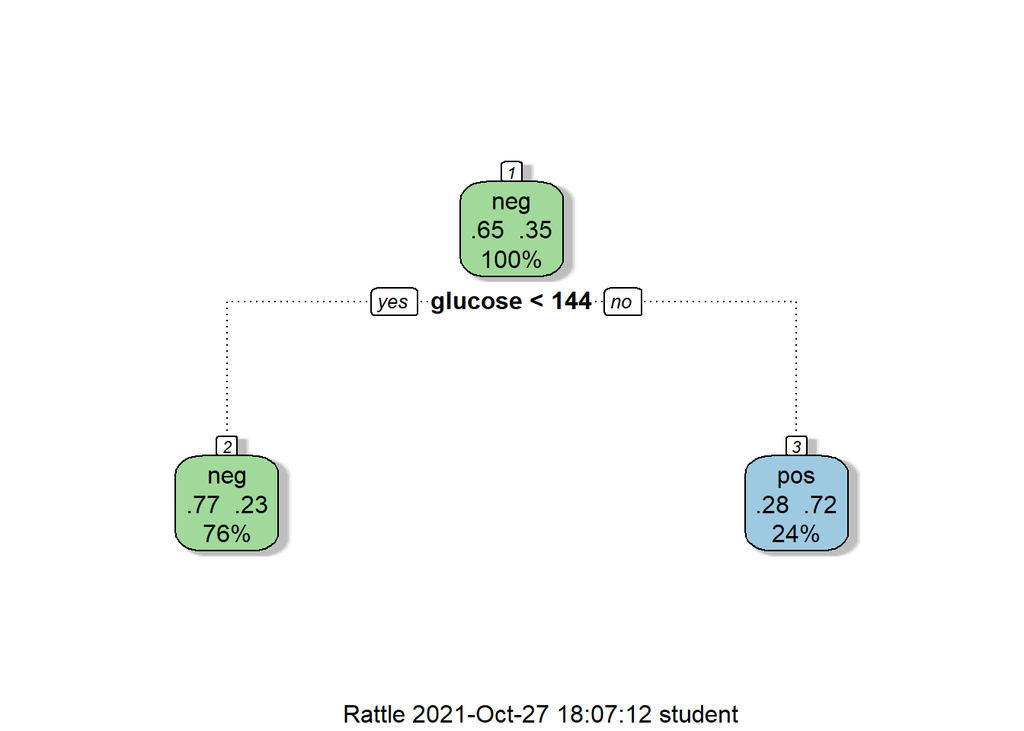

```r
library(rpart)
tree_model <- rpart(target ~ ., data = df_train, control = rpart.control(maxdepth = 3))
library(rattle)
fancyRpartPlot(tree_model)
```

```r
tree_model$variable_importance
```

[output not shown]

3. Practice Random Forest. Do the follows:
- Use `randomForest` package, create a random forest of 1000 trees.
- Calculate the accuracy of the model on the testing data.
- Plot the variable importance by the forest

```r
library(randomForest)
forest_model = randomForest(target ~ ., data=df_train, ntree = 1000)
pred <- predict(forest_model, df_test, type = "class")
cm <- confusionMatrix(data = pred, reference = df_test$target, positive = "pos")
cm$overall[1]
```

```
##  Accuracy
## 0.7908497
```

```r
forest_model$importance
```

```
##          MeanDecreaseGini
## pregnant         22.90061
## glucose          74.01213
## pressure         24.65639
## triceps          19.37641
## insulin          20.69518
## mass             44.06675
## pedigree         34.78747
## age              37.35174
```

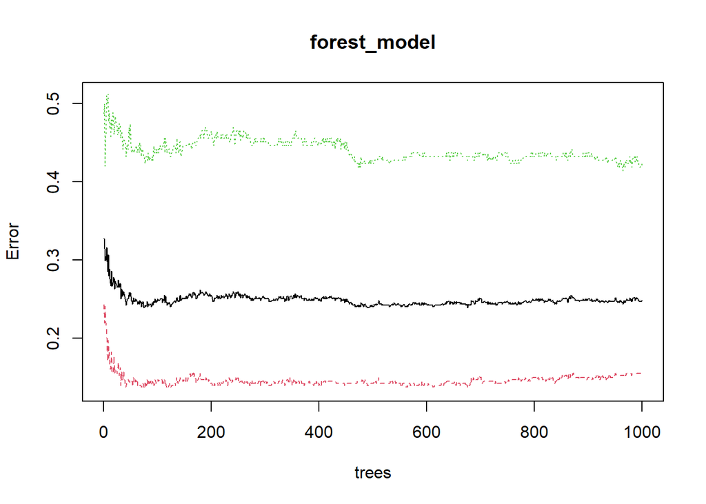

```r
plot(forest_model)
```

4. Compare the testing accuracy of a forest of 1000 trees and a forest of 2000 trees.

```r
library(caret)
library(randomForest)
model1 <- train(target~., data=df_train,
                method = "rf",
                ntree = 1000)
pred <- predict(model1, df_test)
cm <- confusionMatrix(data = pred, reference = df_test$target, positive = "pos")
cm$overall[1]
```

```
##  Accuracy
## 0.7908497
```

```r
model2 <- train(target~., data=df_train,
                method = "rf",
                ntree = 2000)
pred <- predict(model2, df_test)
cm <- confusionMatrix(data = pred, reference = df_test$target, positive = "pos")
cm$overall[1]
```

```
##  Accuracy
## 0.7843137
```

```r
varImp(model1)
```

```
## rf variable importance
##
##          Overall
## glucose  100.000
## mass      49.015
## age       34.140
## pedigree  28.653
## pressure  10.710
## pregnant   5.828
## insulin    3.344
## triceps    0.000
```

```r
varImp(model2)
```

```
## rf variable importance
##
##          Overall
## glucose  100.000
## mass      46.903
## age       32.696
## pedigree  28.189
## pressure   9.853
## pregnant   5.661
## insulin    1.781
## triceps    0.000
```

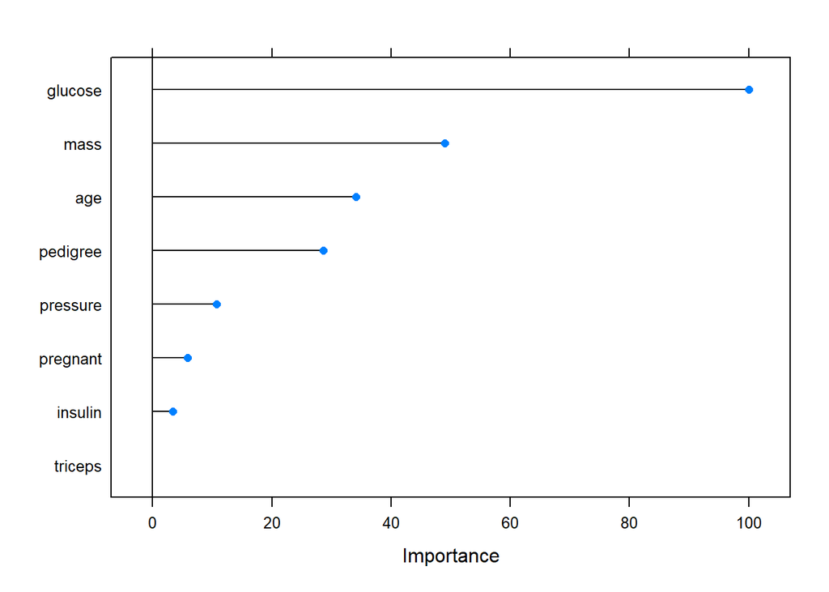

```r
plot(varImp(model1))
```

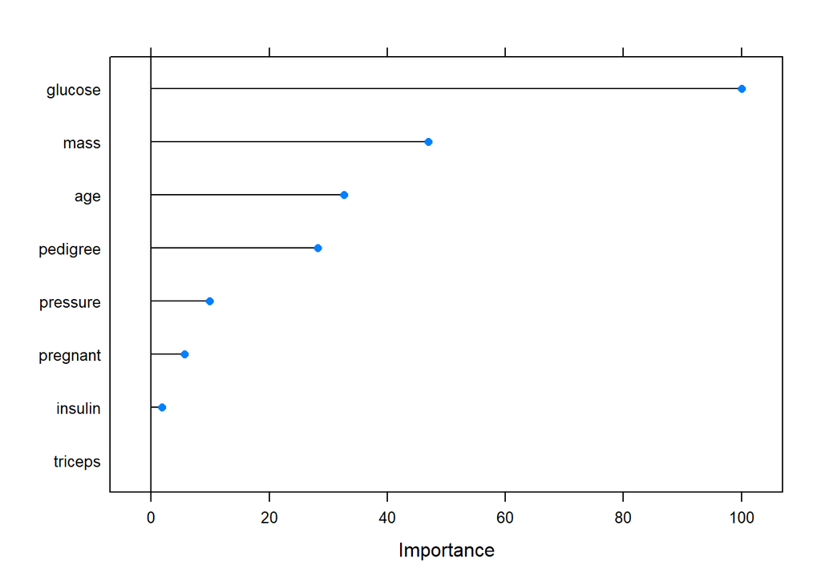

```r
plot(varImp(model2))
```

5. Using Caret, create a tree with maximum depth of 3 and forest of 1000 trees. Compare the accuracy of these two models.
6. Plot variable importance by the two models in 5.

```r
model1 <- train(target~., data=df_train,
                method = "rpart2",
                maxdepth=3)
pred <- predict(model1, df_test)
cm <- confusionMatrix(data = pred, reference = df_test$target, positive = "pos")
cm$overall[1]
```

```
##  Accuracy
## 0.7254902
```

```r
model2 <- train(target~., data=df_train,
                method = "rf",
                ntree = 1000)
pred <- predict(model2, df_test)
cm <- confusionMatrix(data = pred, reference = df_test$target, positive = "pos")
cm$overall[1]
```

```
##  Accuracy
## 0.7712418
```

```r
varImp(model1)
```

```
## rpart2 variable importance
##
##          Overall
## glucose   100.00
## age        49.73
## mass       49.25
## pregnant   24.66
## insulin    18.30
## triceps     0.00
## pedigree    0.00
## pressure    0.00
```

```r
varImp(model2)
```

```
## rf variable importance
##
##          Overall
## glucose  100.000
## mass      44.408
## age       27.887
## pedigree  26.410
## pressure  12.530
## pregnant   5.365
## insulin    2.544
## triceps    0.000
```

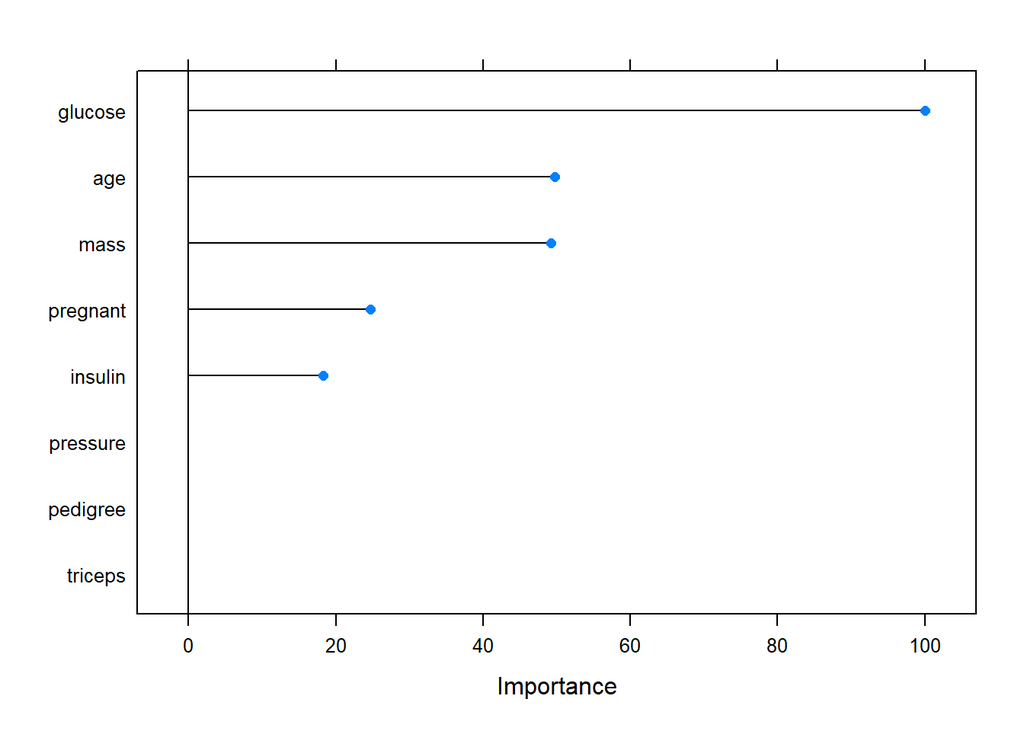

```r
plot(varImp(model1))
```

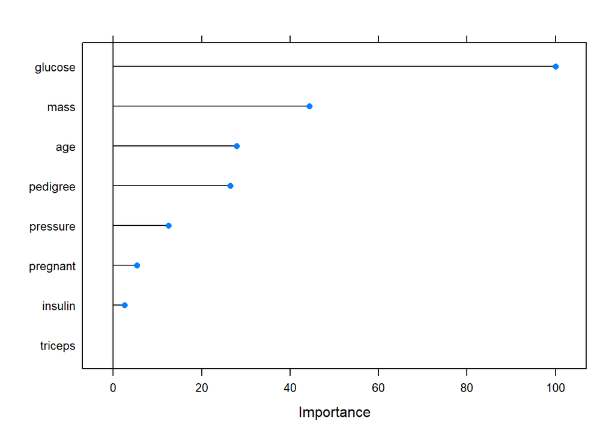

```r
plot(varImp(model2))
```

7. (Optional - For extra credits only) Use your own selected data. Do the follows.
- Handle missing values if any
- Put the variables in the right format (categorical vs. continuous)
- Select a binary target variable (Use can create a binary target variable from a continuous variable).
- Using caret with method `ranger` to train then test the accuracy of a random forest of 1000 trees.